# Modelo lineal generalizado (GLM)

MSc. Darío Alvarado

### GLM con distribución Binomial

Los GLM con distribución binomial también pueden utilizarse para analizar variables que sean una proporción del total de una muestra, por ejemplo, semillas germinadas del total de semillas sembradas por unidad de muestreo, plantas infectadas del total de plantas muestreadas por unidad de muestreo, pacientes recuperados del total de pacientes tratados por unidad de muestreo, etc. Esto es útil cuando nuestras unidades de muestreo no son individuos, sino un grupo de individuos.

#### Paquetes

```r
library(rio)
library(tidyverse)
library(parameters)
library(performance)
library(bbmle)
library(sjPlot)
library(modelbased)
```

### Contenido

#### Datos

```r
semillas <- import("data/germinacion.txt") |>
  mutate_if(is.character, as.factor)
head(semillas)
```

```
##   conteo muestra orobanche extracto
## 1     10      39       a75     bean
## 2     23      62       a75     bean
## 3     23      81       a75     bean
## 4     26      51       a75     bean
## 5     17      39       a75     bean
## 6      5       6       a75 cucumber
```

Esta base de datos es sobre conteos de semillas germinadas (variable “conteo”) del total de las semillas sembradas (variable “muestra”).

La variable “orobanche” tiene dos niveles (“a75” y “a73”), que son las variedades genéticas de las semillas evaluadas.

La variable “extracto” tiene dos niveles (“bean” y “cucumber”), que son dos extractos diferentes que se probaron para ver si tenían algún efecto en la germinación de las semillas.

##### Transformación de la variable respuesta

Para poder analizar el conteo de semillas germinadas tomando en cuenta la muestra, debemos combinar las variables “conteo” y “muestra” restando el “conteo”, para que quede como una proproción:

```r
y <- cbind(semillas$conteo, semillas$muestra - semillas$conteo)
head(y)
```

```
##      [,1] [,2]
## [1,]   10   29
## [2,]   23   39
## [3,]   23   58
## [4,]   26   25
## [5,]   17   22
## [6,]    5    1
```

```r
# así tenemos por un lado las semillas germinadas y por el otro las semillas que no germinaron respecto al total de la muestra.
```

#### Modelo

Podemos aplicar el modelo con la variable “y” que creamos (proporción de semillas germinadas y no germinadas):

```r
binomial1 <- glm(y ~ orobanche + extracto, data = semillas, family = binomial)
```

O podemos hacer la proporción directamente en el modelo:

```r
binomial1 <- glm(cbind(conteo, muestra-conteo) ~ orobanche + extracto, data = semillas, family = binomial)
```

#### Interpretación del modelo

```r
summary(binomial1)
```

```
##
## Call:
## glm(formula = cbind(conteo, muestra - conteo) ~ orobanche + extracto,
##     family = binomial, data = semillas)
##
## Coefficients:
##                  Estimate Std. Error z value Pr(>|z|)
## (Intercept)       -0.7005     0.1507  -4.648 3.36e-06 ***
## orobanchea75       0.2705     0.1547   1.748   0.0804 .
## extractocucumber   1.0647     0.1442   7.383 1.55e-13 ***
## ---
## Signif. codes:  0 '***' 0.001 '**' 0.01 '*' 0.05 '.' 0.1 ' ' 1
##
## (Dispersion parameter for binomial family taken to be 1)
##
##     Null deviance: 98.719  on 20  degrees of freedom
## Residual deviance: 39.686  on 18  degrees of freedom
## AIC: 122.28
##
## Number of Fisher Scoring iterations: 4
```

```r
parameters(binomial1)
```

```
## Parameter           | Log-Odds |   SE |         95% CI |     z |      p
## -----------------------------------------------------------------------
## (Intercept)         |    -0.70 | 0.15 | [-1.00, -0.41] | -4.65 | < .001
## orobanche [a75]     |     0.27 | 0.15 | [-0.03,  0.57] |  1.75 | 0.080
## extracto [cucumber] |     1.06 | 0.14 | [ 0.78,  1.35] |  7.38 | < .001
```

```
##
## Uncertainty intervals (profile-likelihood) and p-values (two-tailed)
##   computed using a Wald z-distribution approximation.
```

```
##
## The model has a log- or logit-link. Consider using `exponentiate =
##   TRUE` to interpret coefficients as ratios.
```

**Los coeficientes están en escala logit**

- Intercepto

```r
plogis(-0.7005)
```

```
## [1] 0.3317014
```

Indica que la probabilidad de que las semillas germinen si son de la variedad genética “a73” y si fueron tratadas con “extracto de frijol” es del 33.17%.

- Coeficientes

“orobanchea [75]”

```r
plogis(-0.7005 + 0.2705)
```

```
## [1] 0.3941263
```

Indica que la probabilidad de que las semillas germinen si son de la variedad genética “a75” y si fueron tratadas con “extracto de frijol” es del 39.41%.

“extracto [cucumber]”

```r
plogis(-0.7005 + 1.0647)
```

```
## [1] 0.5900568
```

Indica que la probabilidad de que las semillas germinen si son de la variedad genética “a73” y si fueron tratadas con “extracto de pepino” es del 59%.

**Para reportar esas probabilidades también debemos reportar el intervalo de confianza al 95%, pero antes hay que validar el modelo.**

#### Validación del modelo

En un modelo binomial para proporciones también puede haber sobredispersión (como en el modelo con distribución de Poisson):

```r
check_overdispersion(binomial1)
```

[output not shown]

[output not shown]

#### Corrección del modelo

Un modelo binomial con sobredispersión puede corregirse cambiando la distribución a **quasibinomial** en el argumento `family =`:

```r
binomial1_q <- glm(cbind(conteo, muestra-conteo) ~ orobanche + extracto, data = semillas, family = quasibinomial)
```

Como sucedía con las correcciones en los modelos con distribución quasiPoisson y binomial negativa para los GLM Poisson que tenían sobredispersión, la corrección que realiza el modelo con distribución quasibinomial para un modelo binomial con sobredispersión está dirigida a corregir el error estándar y los intervalos de confianza.

```r
parameters(binomial1,
           digits = 4,
           ci_digits = 4)
```

```
## Parameter           | Log-Odds |     SE |             95% CI |       z |      p
## -------------------------------------------------------------------------------
## (Intercept)         |  -0.7005 | 0.1507 | [-0.9992, -0.4077] | -4.6475 | < .001
## orobanche [a75]     |   0.2705 | 0.1547 | [-0.0323,  0.5746] |  1.7482 | 0.080
## extracto [cucumber] |   1.0647 | 0.1442 | [ 0.7837,  1.3493] |  7.3831 | < .001
```

```
##
## Uncertainty intervals (profile-likelihood) and p-values (two-tailed)
##   computed using a Wald z-distribution approximation.
```

```r
parameters(binomial1_q,
           digits = 4,
           ci_digits = 4)
```

```
## Parameter           | Log-Odds |     SE |             95% CI |   t(18) |      p
## -------------------------------------------------------------------------------
## (Intercept)         |  -0.7005 | 0.2199 | [-1.1388, -0.2748] | -3.1857 | 0.001
## orobanche [a75]     |   0.2705 | 0.2257 | [-0.1711,  0.7149] |  1.1983 | 0.231
## extracto [cucumber] |   1.0647 | 0.2104 | [ 0.6558,  1.4813] |  5.0608 | < .001
```

```
##
## Uncertainty intervals (profile-likelihood) and p-values (two-tailed)
##   computed using a Wald t-distribution approximation.
```

Ahora si podemos reportar las probabilidades con los intervalos de confianza corregidos.

#### Gráfico del modelo

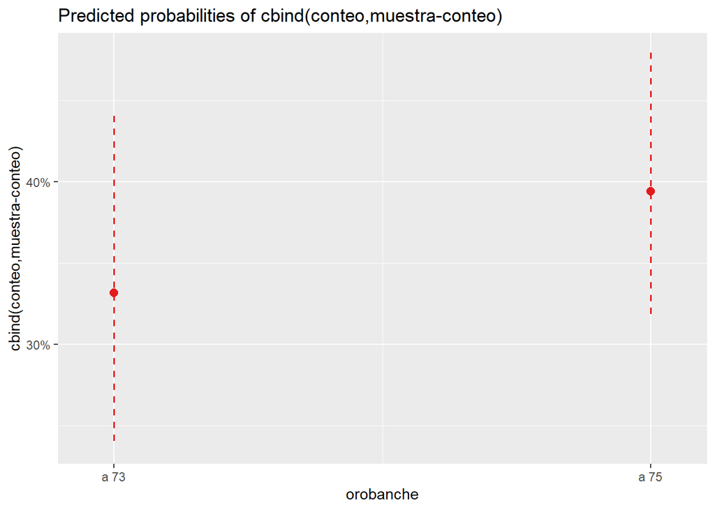

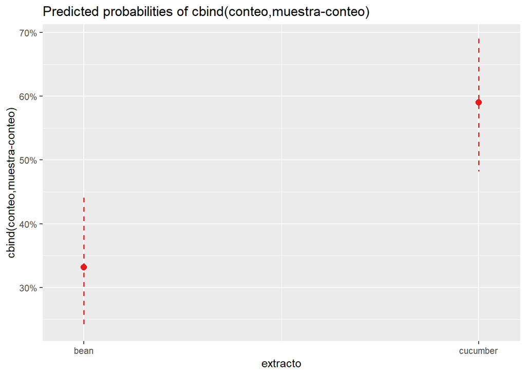

```r
plot_model(binomial1_q,
           type = "pred")
```

#### Selección de modelos

```r
binomial1 <- glm(cbind(conteo, muestra-conteo) ~ orobanche + extracto, data = semillas, family = binomial)
binomial2 <- glm(cbind(conteo, muestra-conteo) ~ orobanche * extracto, data = semillas, family = binomial)
binomial3 <- glm(cbind(conteo, muestra-conteo) ~ orobanche, data = semillas, family = binomial)
binomial4 <- glm(cbind(conteo, muestra-conteo) ~ extracto, data = semillas, family = binomial)
```

Recordemos que la sobredispersión está ligada a la variable respuesta, como consecuencia es muy probable que todos los modelos presenten sobredispersión. Revisemos un par de modelos:

```r
check_overdispersion(binomial2)
```

[output not shown]

[output not shown]

```r
check_overdispersion(binomial3)
```

[output not shown]

```
## Overdispersion detected.
```

Realizamos la corrección de los modelos para la selección:

```r
binomial1_q <- glm(cbind(conteo, muestra-conteo) ~ orobanche + extracto, data = semillas, family = quasibinomial)
binomial2_q <- glm(cbind(conteo, muestra-conteo) ~ orobanche * extracto, data = semillas, family = quasibinomial)
binomial3_q <- glm(cbind(conteo, muestra-conteo) ~ orobanche, data = semillas, family = quasibinomial)
binomial4_q <- glm(cbind(conteo, muestra-conteo) ~ extracto, data = semillas, family = quasibinomial)
```

Y ahora la selección de modelos con la función `compare_performance()` del paquete `performance`:

```r
compare_performance(binomial1_q, binomial2_q, binomial3_q, binomial4_q, rank = TRUE)
```

```
## # Comparison of Model Performance Indices
##
## Name        | Model |  RMSE | Sigma | Performance-Score
## -------------------------------------------------------
## binomial2_q |   glm | 0.137 | 1.364 |           100.00%
## binomial1_q |   glm | 0.145 | 1.459 |            87.28%
## binomial4_q |   glm | 0.159 | 1.473 |            73.89%
## binomial3_q |   glm | 0.192 | 2.195 |             0.00%
```

Con la función `ICtab()` del paquete `bbmle` (similar a la función `AICtab()`:

```r
ICtab(binomial1, binomial2, binomial3, binomial4,
      base = TRUE,
      delta = TRUE,
      weights = TRUE,
      sort = TRUE,
      dispersion = 1.862, # colocamos el valor de sobredispersión de uno de los modelos
      type = "qAIC") # indicamos que la selección sea basada en el qAIC corregido para modelos con distribución "quasi".
```

```
##           qAIC dqAIC df weight
## binomial2 67.0  0.0  4  0.48
## binomial4 68.1  1.1  2  0.28
## binomial1 68.5  1.4  3  0.24
## binomial3 96.8 29.8  2  <0.001
```

Recordemos que el valor de sobredispersión que coloquemos en la función puede afectar la selecció del modelo.

##### Interpretación del mejor modelo

```r
summary(binomial2_q)
```

```
##
## Call:
## glm(formula = cbind(conteo, muestra - conteo) ~ orobanche * extracto,
##     family = quasibinomial, data = semillas)
##
## Coefficients:
##                               Estimate Std. Error t value Pr(>|t|)
## (Intercept)                    -0.4122     0.2513  -1.640   0.1193
## orobanchea75                   -0.1459     0.3045  -0.479   0.6379
## extractocucumber                0.5401     0.3409   1.584   0.1315
## orobanchea75:extractocucumber   0.7781     0.4181   1.861   0.0801 .
## ---
## Signif. codes:  0 '***' 0.001 '**' 0.01 '*' 0.05 '.' 0.1 ' ' 1
##
## (Dispersion parameter for quasibinomial family taken to be 1.861832)
##
##     Null deviance: 98.719  on 20  degrees of freedom
## Residual deviance: 33.278  on 17  degrees of freedom
## AIC: NA
##
## Number of Fisher Scoring iterations: 4
```

```r
parameters(binomial2_q)
```

```
## Parameter                             | Log-Odds |   SE |        95% CI | t(17) |     p
## ---------------------------------------------------------------------------------------
## (Intercept)                           |    -0.41 | 0.25 | [-0.92, 0.07] | -1.64 | 0.101
## orobanche [a75]                       |    -0.15 | 0.30 | [-0.74, 0.46] | -0.48 | 0.632
## extracto [cucumber]                   |     0.54 | 0.34 | [-0.12, 1.22] |  1.58 | 0.113
## orobanche [a75] × extracto [cucumber] |     0.78 | 0.42 | [-0.04, 1.60] |  1.86 | 0.063
```

```
##
## Uncertainty intervals (profile-likelihood) and p-values (two-tailed)
##   computed using a Wald t-distribution approximation.
```

Estimamos las probabilidades indicando los valores condicionales en un dataframe:

```r
condicionales_semillas <- (data.frame(orobanche = c("a73", "a73", "a75", "a75"), extracto = c("bean", "cucumber", "bean", "cucumber")))
condicionales_semillas
```

```
##   orobanche extracto
## 1       a73     bean
## 2       a73 cucumber
## 3       a75     bean
## 4       a75 cucumber
```

Aplicamos la función `estimate_expectation()` del paquete `modelbased` para calcular las probabilidades:

```r
estimate_expectation(binomial2_q, data = condicionales_semillas)
```

```
## Model-based Predictions
##
## orobanche | extracto | Predicted |   SE |       95% CI
## ------------------------------------------------------
## a73       | bean     |      0.40 | 0.06 | [0.28, 0.53]
## a73       | cucumber |      0.53 | 0.06 | [0.41, 0.65]
## a75       | bean     |      0.36 | 0.04 | [0.28, 0.45]
## a75       | cucumber |      0.68 | 0.04 | [0.60, 0.75]
##
## Variable predicted: cbind(conteo, muestra - conteo)
## Predictions are on the response-scale.
```

Podemos comprobar las probabilidades con el gráfico del modelo.

##### Gráfico del mejor modelo

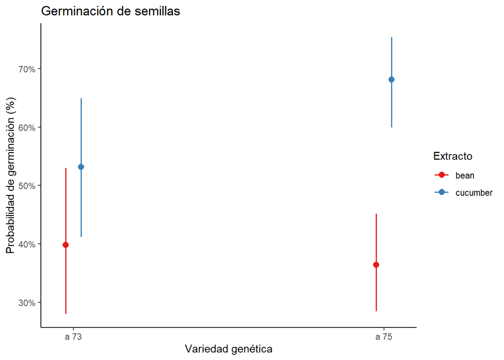

```r
plot_model(binomial2_q,
           type = "int",
           terms = c("orobanche", "extracto")) +
  labs(title = "Germinación de semillas",
       y = "Probabilidad de germinación (%)",
       x = "Variedad genética",
       color = "Extracto") +
  theme_classic()
```

Inicio